# HF 1 (15 pont)

- Minden feladatot a feladatszámnak megfelelő számú megoldásnotebookban oldj meg. Az első feladatot az feladat01.ipynb notebookban és így tovább.
- A megoldás tartalmazza a megoldandó feladat szövegét a megoldásnotebook első markdown cellájában!
- **Kommentekkel**, illetve **markdown cellákkal** magyarázd, hogy éppen mit csinál az adott kódrészlet!
- Magyarázat nélkül a beküldött feladatok csak fél feladatnak számítanak!
- Az elkészített ábrák minden esetben rendelkezzenek ábrafeliratokkal (cím, tengelyfeliratok és − amennyiben indokolt − jelmagyarázat)! Amennyiben a beadott ábrákon nincsenek feliratok, az adott feladat automatikusan csak fél feladatnak számít!
- A beadott notebookok Kernel -> Restart&Run All hatására a beadott formát reprodukálják! (Próbáld ki!)

## Feladat 5 (2.5 pont)

Készíts egy "Interpolator" nevű osztályt, ami [lineáris interpolációt](https://en.wikipedia.org/wiki/Linear_interpolation) valósít meg:

- Inicializáláskor két `array`-t várjon el. (0.75p)
  - Az első az interpoláláshoz használt pontok $x$ koordinátáját tartalmazza.
  - A második az interpoláláshoz használt pontok $y$ koordinátáját tartalmazza.
  - Feltételezheted, hogy minden $x$ érték csak egyszer szerepel a kapott adatokban.
  - Tudja kezelni a programod azt is, ha a számok az $x$-ben nem növekvő sorrendben követik egymást! Ennek a figyelembevételénél segítségedre lehet a `numpy` modul [`argsort`](https://numpy.org/doc/stable/reference/generated/numpy.argsort.html) függvénye.
- Van egy "add" osztálymetódusa, ami két bemeneti változót vár el: egy adott pont $x$ és $y$ koordinátáját, ebben a sorrendben. Ha van már azonos $x$ koordinátájú pont az interpolációhoz használt pontok között, akkor írja ki a program, hogy "Ilyen x már van benne!", viszont ha nincs, akkor adja hozzá az új pontot a pontokat tartalmazó megfelelő array-ekhez. (0.25p)
- Van egy "remove" osztálymetódusa, ami egy bemeneti változót vár el: egy adott pont $x$ koordinátáját. Ha nincs még adott $x$ koordinátájú pont az interpolációhoz használt pontok között, akkor írja ki a program, hogy "Ilyen x még nincs benne!", viszont ha van, akkor vegye ki a hozzá tartozó $y$ értékkel együtt. (0.25p)
- Van egy "interpolate" nevű osztálymetódusa, ami egy bemeneti változót vár el: egy `array` típusú válltozót, ami az interpolálandó pontok $x$ koordinátáját tartalmazza, nem feltétlenül növekvő sorrendben. Ha minden $x$ érték az interpoláláshoz használt pontok maximuma és minimuma között van, akkor a függvény végezze el a lineáris interpolációt az adott pontokra és térjen vissza egy `array`-el, ami az adott $x$-ekhez tartozó $y$ értékeket tartalmazza. Ha viszont nem, akkor **írja ki**, hogy "Valamelyik x nincs benne az adott intervallumban!" és a **visszatérési értéke** legyen `None`! (0.5p)

Ezután mutasd be 1-1 általad választott példán, hogy a hibaüzenetek tényleg megjelennek! (0.25p)

Végül pedig mintavételezd egyenletesen a $[0, 2\pi]$ intervallumot 10 pontban (x) és értékeld ki a $\sin(x)$ függvényt ezekben a pontokban (y) és készíts egy példányt az osztályodból ezekkel a pontokkal! Mintavételezd a $[0, 2\pi]$ ismét (u), de most 1000 pontban és értékeld ki az interpolátort ezeken a pontokon (v)! Ezek után ábrázold egy ábrán a két összetartozó sorozatot, azaz y-t x függvényében és v-t u függvényében úgy, hogy mindkét függvény látszódjon az ábrán! Mit tapasztalsz? Fogalmazd meg a saját szavaiddal! (0.5p)

A megoldásod során **Tilos** a `numpy` vagy a `scipy` modul, vagy bármely más python csomag, konkrétan interpolációra megírt függvényeit használni. Amenyiben a kódodban ezt teszed a feladatod automatikusan 0.0p-t ér!

```python
import matplotlib.pyplot as mpl
import numpy as np
```

```python
class Interpolator:

    def __init__(self,array1,array2): # kettő arrayt várok
        self.x=array1 # x legyen az első
        self.y=array2 # y a második
        xhelyek=np.argsort(self.x) # megnézem milyen sorrendben vannak
        xhelyes=[] # létrehozok egy listát amibe pakolom majd helyes sorrendben az x-eket
        yhelyes=[] # same in y
        for k in range(0,len(xhelyek)): # végigmegyek a beadot x listámon
            xhelyes.append(self.x[xhelyek[k]]) # berakom a jó sorrendben az x-ekhez
            yhelyes.append(self.y[xhelyek[k]]) # az xhez kapcsolódóan adom be az y-ba az elemeimet
        self.x=np.array(xhelyes) # array tipusu változóvá akarom tenni
        self.y=np.array(yhelyes) # ezt is
    def add(self,ujx,ujy): # 2 új értéket akarok várni
        if len(np.where(self.x==ujx)[0])==0: # hogyha annak a listája ami ugyanolyan mint a már meglévő elememeim hossza 0
            self.x=np.append(self.x,ujx) # akkor adogatom be az elemeket, amiket újként megadok
            self.y=np.append(self.y,ujy) # y-okora is megteszem
            xhelyek=np.argsort(self.x) # ugyanúgy sorba rendezem mint az initben
            xhelyes=[]
            yhelyes=[]
            for k in range(0,len(xhelyek)):
                xhelyes.append(self.x[xhelyek[k]])
                yhelyes.append(self.y[xhelyek[k]])
            self.x=np.array(xhelyes)
            self.y=np.array(yhelyes)
        else:                          # hogyha akár 1 elemet is talál ami már volt,
            print("Ilyen x már van benne!")      # akkor ki akarom iratni, hogy ilyen már volt benne
    def remove (self,regix): # definiiálom az eltávolítást
        if len(np.where(self.x==regix)[0])!=0: # megfordítom az addolásnál, ha nem 0 az azonos elemeim halmaza
            self.y=np.delete(self.y,np.where(self.x==regix)[0]) # akkor kiszedem
            self.x=np.delete(self.x,np.where(self.x==regix)[0])# a hozzá tartozó értéket is kiszedem  (x.index(regix))
        else:  #   máskülönben kiirom,
            print("Ilyen x még nincs benne!") # hogy még nem volt benne ilyen
    def interpolate (self,xarray): # interpolálok is
        if max(xarray)> max(self.x) or min(xarray)<min(self.x): #hogyha kilóg allulról vagy fellülről
            print("Valamelyik x nincs benne az adott intervallumban!") #akkor kiabálok, hogy ez nem tetszik
            return(None) # ez esetben azt akarom kapni, hogy "None"
        else: # de ha jók az értékeim
            xhelyek2=np.argsort(xarray) # egyszer sorrendbe akarom rakni
            yhelyek2=[] # úgy ahogy az initben is
            xhelyes2=[]
            for k in range(0,len(xhelyek2)): # végigmegyek a listán
                j=min(np.where(self.x>=xarray[xhelyek2[k]])[0]) # lásd a markdownbon alatta
                i=j-1
                xhelyes2.append(xarray[xhelyek2[k]])
                yhelyek2.append((self.y[i]+((self.y[j]-self.y[i])*((xarray[xhelyek2[k]]-self.x[i])/(self.x[j]-self.x[i])))))
        return(xhelyes2,yhelyek2)
```

j-nek elnevezem azt az értéket, ami az új értékeimet határolja legszorosabban. avagy a legnagyobb új értékemet határoló fellülről legkisebb régi értékem i-m az j-1, azaz a legnagyobb új értékem alatta lévő sorban befelyezem a rendberakásomat. azalatt a képletem található vissza akarok térni az x és y-jaimmal

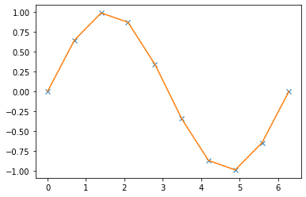

```python
x=np.linspace(0,2*np.pi,10) # a megadott értékek alapján generálok 10,
u=np.linspace(0,2*np.pi,1000) # illetve 1000 egyenletesen elosztott számot
y=np.sin(x) # kell nekem egy sinusz is
i=Interpolator(x,y) # kell nekem hogy Interpolator Classban legyek  , és elnevezem i-nek
v,y2=i.interpolate(u) # v és y2-re nézem meg, azt, ahogy interpolárok is u szerint
mpl.plot(x,y,"x") # plotolok, és a láthatóság érdeke miatt x-el jelölöm a pontjaimat
mpl.plot(v,y2) # mert amúgymeg tökéletesen egymásra esnek
```

```python
plusszok=Interpolator([5,6,7,2],[3,2,7,2])
plusszok.add(5,2)
plusszok.interpolate([1,3,6])
plusszok.remove(1)
```

```
Ilyen x már van benne!
Valamelyik x nincs benne az adott intervallumban!
Ilyen x még nincs benne!
```